# Forecasting Lifting Accuracy with Machine Learning

# Overview

The data for this project was developed by: http://groupware.les.inf.puc-rio.br/har

The training data for this project is available here: https://d396qusza40orc.cloudfront.net/predmachlearn/pml-training.csv

The test data for this project is available here: https://d396qusza40orc.cloudfront.net/predmachlearn/pml-testing.csv

# Load libraries

[output not shown]

[output not shown]

[output not shown]

[output not shown]

[output not shown]

[output not shown]

[output not shown]

[output not shown]

[output not shown]

[output not shown]

[output not shown]

[output not shown]

[output not shown]

[output not shown]

[output not shown]

[output not shown]

# Testing and Training Data Sets

We begin by loading the pml-training data set and examining its structure. The structure of the training data set shows that many of the variables are in the incorrect format (e.g. numeric variables are factors and time variables aren't properly formatted).

```r
dat = read.csv(trainLoc, header = TRUE)
str(dat)
```

```
## 'data.frame':    19622 obs. of  160 variables:
##  $ X                       : int  1 2 3 4 5 6 7 8 9 10 ...
##  $ user_name               : Factor w/ 6 levels "adelmo","carlitos",..: 2 2 2 2 2 2 2 2 2 2 ...
##  $ raw_timestamp_part_1    : int  1323084231 1323084231 1323084231 1323084232 1323084232 1323084232 1323084232 1323084232 1323084232 1323084232 ...
##  $ raw_timestamp_part_2    : int  788290 808298 820366 120339 196328 304277 368296 440390 484323 484434 ...
##  $ cvtd_timestamp          : Factor w/ 20 levels "02/12/2011 13:32",..: 9 9 9 9 9 9 9 9 9 9 ...
##  $ new_window              : Factor w/ 2 levels "no","yes": 1 1 1 1 1 1 1 1 1 1 ...
##  $ num_window              : int  11 11 11 12 12 12 12 12 12 12 ...
##  $ roll_belt               : num  1.41 1.41 1.42 1.48 1.48 1.45 1.42 1.42 1.43 1.45 ...
##  $ pitch_belt              : num  8.07 8.07 8.07 8.05 8.07 8.06 8.09 8.13 8.16 8.17 ...
##  $ yaw_belt                : num  -94.4 -94.4 -94.4 -94.4 -94.4 -94.4 -94.4 -94.4 -94.4 -94.4 ...
##  $ total_accel_belt        : int  3 3 3 3 3 3 3 3 3 3 ...
##  $ kurtosis_roll_belt      : Factor w/ 397 levels "","-0.016850",..: 1 1 1 1 1 1 1 1 1 1 ...
##  $ kurtosis_picth_belt     : Factor w/ 317 levels "","-0.021887",..: 1 1 1 1 1 1 1 1 1 1 ...
##  $ kurtosis_yaw_belt       : Factor w/ 2 levels "","#DIV/0!": 1 1 1 1 1 1 1 1 1 1 ...
```

[output cut: 86 more lines]

We next divide the training data set into training and testing subsets, using 80% of the initial training data set for the sub-train data set.

```r
inTrain <- createDataPartition(y = dat$classe, p = 0.8, list = FALSE)
training = dat[inTrain, ]
testing = dat[-inTrain, ]
```

# Preprocessing Functions

We developed a set of preprocessing functions for converting the columns of the training data to their correct formats and for removing variables from the dataset with zero variance; zero variance variables do not explain the variance of the outcome variable, classe, and so add noise. The main preprocessing function calls a number of other functions, each designed to achieve the purpose described by its name.

```r
preProcessData <- function(dataset) {
    # Convert columns that should be numeric to numeric
    dataset <- convertFactorsToNumeric(dataset)
    dataset <- convertToNumeric(dataset)
    # Convert covariates that should be in date/time format to date/time format
    dataset <- convertToDateTime(dataset)
    # Create dummy variables from user_name, new_window
    dataset <- removeZeroVar(dataset)
    return(dataset)
}
```

The first function converts factor variables that should be numeric to numeric variables:

```r
convertFactorsToNumeric <- function(dataset) {
    # Convert factor vectors that should be numeric to numeric
    factor_col <- lapply(dataset, class) == "factor"
    factor_col_names <- array(names(dataset[, factor_col == TRUE]))
    factor_col <- which(colnames(dataset) %in% factor_col_names)
    nFactorCols <- nrow(factor_col_names)
    factor_col <- factor_col[-c(1, 2, 3, nFactorCols)]  # Don't convert factor variables that are categorical
    dataset[, factor_col] <- lapply(dataset[, factor_col], as.character)
    dataset[, factor_col] <- lapply(dataset[, factor_col], as.numeric)
    return(dataset)
}
```

The second function converts all other variables types that should be numeric to numeric:

```r
convertToNumeric <- function(dataset) {
    # Convert all columns that should be numeric and that are not factors to
    # numeric
    lastCol <- ncol(dataset)
    nonNumericCols <- c(1, 2, 3, 4, 5, 6, 7, lastCol)
    dataset[, -nonNumericCols] <- lapply(dataset[, -nonNumericCols], as.numeric)
    return(dataset)
}
```

The third function converts date/time fields to their appropriate format:

```r
convertToDateTime <- function(dataset) {
    dataset$cvtd_timestamp <- dmy_hm(dataset$cvtd_timestamp)
    return(dataset)
}
```

The fourth function removes variables with zero variation:

```r
removeZeroVar <- function(dataset) {
    nsv <- nearZeroVar(dataset, saveMetrics = TRUE)
    dataset <- dataset[, nsv$nzv == FALSE]
    return(dataset)
}
```

Functions 5-7 calculate the percent of each column in a data frame that consists of NA's so that covariates with a high percentage of NA's can be removed.

```r
percentNA <- function(dataset) {
    naPercent <- naCount(dataset)/colLength(dataset)
}

naCount <- function(x) sapply(x, function(y) sum(is.na(y)))
colLength <- function(x) sapply(x, function(y) length(y))
```

# Preprocessing

The core set of code does three things: preprocesses the training data, analyzes the covariates and builds a prediction model.

The following line of code preprocess the data using the functions previously loaded:

```r
training <- preProcessData(training)
```

[output not shown]

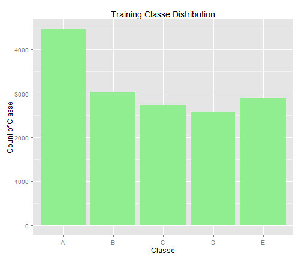

```r
ggp <- ggplot(training, aes(x = classe))
ggp + geom_histogram(fill = "lightgreen") + ggtitle("Training Classe Distribution") +
    labs(x = "Classe", y = "Count of Classe")
```

Remove the first six variables from the training data set since they are descriptive and add little to no predictive value.

```r
training <- training[, -c(1:6)]
```

Remove variables with a majority of NA values.

```r
percentNA <- percentNA(training)
majorityNA <- names(percentNA[percentNA > 0.5])
training <- training[, !names(training) %in% majorityNA]
```

# Correlation Analysis

Calculate correlations among covariates.

```r
predictors <- training[, -ncol(training)]
corMatrix <- abs(cor(predictors))
diag(corMatrix) <- 0
```

The following chart shows that many of the variables are highly correlated and can be removed. We remove correlated covariates because they explain the same behavior and are duplicative:

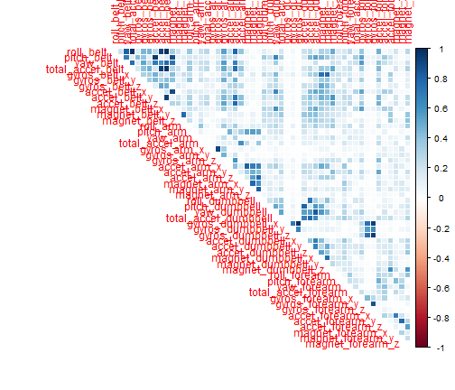

```r
corrplot(corMatrix, type = "upper", method = "color")
```

Remove correlated covariates:

```r
highlyCor <- findCorrelation(corMatrix, 0.7)
training <- training[, -highlyCor]
```

# Most Significant Variable Analysis

Create a random forest model to find the most important covariates

```r
set.seed(1234)
rfFit <- randomForest(classe ~ ., data = training, importance = TRUE, ntree = 100)
```

The variable fits show that much of the variation, whether explained by the decrease in accuracy or the Gini coefficient, is explained by the top 10-15 variables:

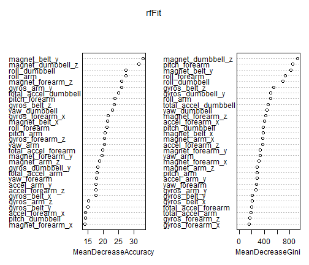

```r
varImpPlot(rfFit)
```

# Model Development

We now train two different machine learning models, Linear Discriminant Analysis (LDA) and Random Forest (RF) on the Training data set using PCA to preprocess the data (Note: I saved modrf and am reloading it for purposes of saving time rather than rerunning the model.

Preprocessing the data using PCA will find the minimal number of covariates out of the 30 covariates that explains the maximum amount of variation.

The Random Forest model is built by taking the training data set and bootstrapping both the variables and the data. The tree starts by building predictions on 5 different variables at each split. Using these variables, the tree predicts the outcome of classe. The tree then splits and at each additional split, it again tries to estimate classe using 5 of the variables out of the 30 variables in the remaining data set. The result of splitting multiple times produces 500 separate trees, each with a prediction. The predictions are averaged to produce an overall prediction of the classe variable. A printout of the random forest model results and confusion matrix (cross-validation) is presented.

Linear Discriminant Analysis predicts the probability of an observation being in a certain class based on a linear combination of the 30 covariates in the prediction data set. It basically asks the question: “what is the probability of this observation being in class A-E given the values of the covariates of this observation?”

```r
modlda <- train(classe ~ ., data = training, method = "lda", preProcess = "pca")
modrf <- readRDS("rfModel.RDS")

modrf
```

```
##
## Call:
##  randomForest(formula = classe ~ ., data = training, importance = TRUE,      preProcess = "pca")
##                Type of random forest: classification
##                      Number of trees: 500
## No. of variables tried at each split: 5
##
##         OOB estimate of  error rate: 1.11%
## Confusion matrix:
##      A    B    C    D    E class.error
## A 4457    6    0    0    1    0.001568
## B   29 2996   10    1    2    0.013825
## C    1   29 2688   20    0    0.018262
## D    0    0   58 2509    6    0.024874
## E    0    1    2    8 2875    0.003812
```

```r
pTrainLDA <- predict(modlda, training)
pTrainRF <- predict(modrf, training)
confusionMatrix(pTrainLDA, training$classe)
```

```
## Confusion Matrix and Statistics
##
##           Reference
## Prediction    A    B    C    D    E
##          A 2971  702  698  178  265
##          B  536 1206  280  560  501
##          C  502  542 1450  424  426
##          D  428  420  203 1139  323
##          E   27  168  107  272 1371
##
## Overall Statistics
##
##                Accuracy : 0.518
##                  95% CI : (0.51, 0.526)
##     No Information Rate : 0.284
##     P-Value [Acc > NIR] : <2e-16
##
##                   Kappa : 0.389
##  Mcnemar's Test P-Value : <2e-16
##
## Statistics by Class:
##
##                      Class: A Class: B Class: C Class: D Class: E
## Sensitivity             0.666   0.3970   0.5296   0.4427   0.4751
## Specificity             0.836   0.8517   0.8539   0.8953   0.9552
## Pos Pred Value          0.617   0.3912   0.4336   0.4532   0.7049
## Neg Pred Value          0.863   0.8548   0.8958   0.8912   0.8899
## Prevalence              0.284   0.1935   0.1744   0.1639   0.1838
## Detection Rate          0.189   0.0768   0.0924   0.0726   0.0873
## Detection Prevalence    0.307   0.1964   0.2130   0.1601   0.1239
## Balanced Accuracy       0.751   0.6244   0.6917   0.6690   0.7151
```

```r
confusionMatrix(pTrainRF, training$classe)
```

```
## Confusion Matrix and Statistics
##
##           Reference
## Prediction    A    B    C    D    E
##          A 4460    9    0    0    0
##          B    4 3025    5    0    0
##          C    0    2 2732   11    0
##          D    0    0    1 2556    2
##          E    0    2    0    6 2884
##
## Overall Statistics
##
##                Accuracy : 0.997
##                  95% CI : (0.996, 0.998)
##     No Information Rate : 0.284
##     P-Value [Acc > NIR] : <2e-16
##
##                   Kappa : 0.997
##  Mcnemar's Test P-Value : NA
##
## Statistics by Class:
##
##                      Class: A Class: B Class: C Class: D Class: E
## Sensitivity             0.999    0.996    0.998    0.993    0.999
## Specificity             0.999    0.999    0.999    1.000    0.999
## Pos Pred Value          0.998    0.997    0.995    0.999    0.997
## Neg Pred Value          1.000    0.999    1.000    0.999    1.000
## Prevalence              0.284    0.194    0.174    0.164    0.184
## Detection Rate          0.284    0.193    0.174    0.163    0.184
## Detection Prevalence    0.285    0.193    0.175    0.163    0.184
## Balanced Accuracy       0.999    0.998    0.998    0.997    0.999
```

# Prediction

Using the models developed in the prior step, we predict the outcomes of the testing data set using the Linear Discriminant and Random Forest models.

```r
plda <- predict(modlda, testing)
prf <- predict(modrf, testing)
```

# Model Accuracy

```r
confusionMatrix(plda, testing$classe)
```

```
## Confusion Matrix and Statistics
##
##           Reference
## Prediction   A   B   C   D   E
##          A 766 176 174  40  54
##          B 130 293  69 144 125
##          C 110 128 356 106 113
##          D 103 111  56 287  95
##          E   7  51  29  66 334
##
## Overall Statistics
##
##                Accuracy : 0.519
##                  95% CI : (0.503, 0.535)
##     No Information Rate : 0.284
##     P-Value [Acc > NIR] : <2e-16
##
##                   Kappa : 0.39
##  Mcnemar's Test P-Value : <2e-16
##
## Statistics by Class:
##
##                      Class: A Class: B Class: C Class: D Class: E
## Sensitivity             0.686   0.3860   0.5205   0.4463   0.4632
## Specificity             0.842   0.8521   0.8589   0.8887   0.9522
## Pos Pred Value          0.633   0.3850   0.4379   0.4402   0.6858
## Neg Pred Value          0.871   0.8526   0.8945   0.8912   0.8874
## Prevalence              0.284   0.1935   0.1744   0.1639   0.1838
## Detection Rate          0.195   0.0747   0.0907   0.0732   0.0851
## Detection Prevalence    0.308   0.1940   0.2072   0.1662   0.1241
## Balanced Accuracy       0.764   0.6191   0.6897   0.6675   0.7077
```

```r
confusionMatrix(prf, testing$classe)
```

```
## Confusion Matrix and Statistics
##
##           Reference
## Prediction    A    B    C    D    E
##          A 1115    0    0    0    0
##          B    1  759    4    0    0
##          C    0    0  680    3    0
##          D    0    0    0  640    0
##          E    0    0    0    0  721
##
## Overall Statistics
##
##                Accuracy : 0.998
##                  95% CI : (0.996, 0.999)
##     No Information Rate : 0.284
##     P-Value [Acc > NIR] : <2e-16
##
##                   Kappa : 0.997
##  Mcnemar's Test P-Value : NA
##
## Statistics by Class:
##
##                      Class: A Class: B Class: C Class: D Class: E
## Sensitivity             0.999    1.000    0.994    0.995    1.000
## Specificity             1.000    0.998    0.999    1.000    1.000
## Pos Pred Value          1.000    0.993    0.996    1.000    1.000
## Neg Pred Value          1.000    1.000    0.999    0.999    1.000
## Prevalence              0.284    0.193    0.174    0.164    0.184
## Detection Rate          0.284    0.193    0.173    0.163    0.184
## Detection Prevalence    0.284    0.195    0.174    0.163    0.184
## Balanced Accuracy       1.000    0.999    0.997    0.998    1.000
```

```r
table(prf, testing$classe)
```

```
##
## prf    A    B    C    D    E
##   A 1115    0    0    0    0
##   B    1  759    4    0    0
##   C    0    0  680    3    0
##   D    0    0    0  640    0
##   E    0    0    0    0  721
```